# PS2

Question 1

```python
import pandas as pd
from sklearn.model_selection import train_test_split
import numpy as np
import matplotlib.pyplot as plt
from sklearn.linear_model import LinearRegression
from sklearn.metrics import mean_squared_error, r2_score
from sklearn.preprocessing import StandardScaler
from sklearn.linear_model import Lasso, Ridge, ElasticNet
from sklearn.ensemble import RandomForestRegressor, GradientBoostingRegressor
```

```python
# 1

# read the file
file_path = "D:/Georgetown/25spring semester/DS2/problem sets/PS2/nyc_airbnb_listings.csv"
df = pd.read_csv(file_path)

# Then check which columns have missing values.
missing_values = df.isnull().sum()

# Then need to eliminate the missing values.
num_fill_median = ["bathrooms", "bedrooms", "beds", "host_response_rate", "host_acceptance_rate", "host_listings_count", "host_total_listings_count"]
df[num_fill_median] = df[num_fill_median].fillna(df[num_fill_median].median())

# Now fill the boolean class with the most common value.
bool_fill_mode = ["host_has_profile_pic", "host_identity_verified", "host_is_superhost"]
df[bool_fill_mode] = df[bool_fill_mode].fillna(df[bool_fill_mode].mode(dropna=True).iloc[0])

# Now fill the variable related with money
money_fill_zero = ["security_deposit", "cleaning_fee"] # Some apartments really don't have these fees.
df[money_fill_zero] = df[money_fill_zero].fillna(0)

# Fill the columns related with review_scores with mean value. because they are all from 1~10.
review_cols = [col for col in df.columns if "review_scores" in col]
df[review_cols] = df[review_cols].fillna(df[review_cols].mean())

# Fill the reviews_per_month with 0, because it means no reviews.
df["reviews_per_month"] = df["reviews_per_month"].fillna(0)

# Then check which columns have missing values one more time.
missing_values = df.isnull().sum()

# Then need to convert the categorical variables to dummy variables.
df = pd.get_dummies(df, columns=["neighbourhood_group", "room_type"], drop_first=True)

# Now I am going to split the data into training and testing data.
# Choose the price as the target variable.
X = df.drop(columns=["price"])
y = df["price"]

# Split the data into training and testing data.
X_train, X_test, y_train, y_test = train_test_split(X, y, test_size=0.3, random_state=42)

scaler = StandardScaler()
X_train = scaler.fit_transform(X_train)
X_test = scaler.transform(X_test)

print("train set:",X_train.shape, y_train.shape)
print("test_set:",X_test.shape, y_test.shape)
```

```
train set: (35557, 40) (35557,)
test_set: (15239, 40) (15239,)
```

```
Mean Squared Error (MSE): 126806.86
R^2 Score: 0.0859
```

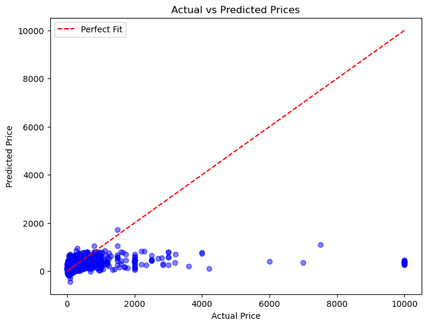

```python
# 2

# Initialize and train the linear regression model
model = LinearRegression()
model.fit(X_train, y_train)

# Make predictions
y_pred = model.predict(X_test)

# Calculate performance metrics
mse = mean_squared_error(y_test, y_pred)
r2 = r2_score(y_test, y_pred)

# Print MSE and R^2 scores
print(f"Mean Squared Error (MSE): {mse:.2f}")
print(f"R^2 Score: {r2:.4f}")

# **Plot Actual vs Predicted Prices**
plt.figure(figsize=(8, 6))
plt.scatter(y_test, y_pred, alpha=0.5, color="blue")
plt.plot([min(y_test), max(y_test)], [min(y_test), max(y_test)], linestyle="--", color="red", label="Perfect Fit")
plt.xlabel("Actual Price")
plt.ylabel("Predicted Price")
plt.title("Actual vs Predicted Prices")
plt.legend()
plt.show()
```

```python
# 3

# function to train and evaluate a model
def train_evaluate(model, model_name):
    model.fit(X_train, y_train)
    y_pred = model.predict(X_test)

    mse = mean_squared_error(y_test, y_pred)
    r2 = r2_score(y_test, y_pred)

    num_zero_coeffs = np.sum(model.coef_==0)

    print(f"{model_name}:")
    print(f"Mean Squared Error (MSE): {mse:.2f}")
    print(f"R^2 Score: {r2:.4f}")
    print(f"Number of Zero Coefficients: {num_zero_coeffs}/{len(model.coef_)}")
    print("-" * 50)


lasso_05 = Lasso(alpha=0.5)
train_evaluate(lasso_05, "LASSO(alpha=0.5)")

lasso_50 = Lasso(alpha=0.5)
train_evaluate(lasso_50, "LASSO(alpha=5.0)")

ridge = Ridge(alpha=1.0)
train_evaluate(ridge, "Ridge Regression")

elastic_net = ElasticNet(alpha=1.0, l1_ratio=0.5)
train_evaluate(elastic_net, "Elastic Net Regression")
```

```
LASSO(alpha=0.5):
Mean Squared Error (MSE): 126693.60
R^2 Score: 0.0867
Number of Zero Coefficients: 1/40
--------------------------------------------------
LASSO(alpha=5.0):
Mean Squared Error (MSE): 126693.60
R^2 Score: 0.0867
Number of Zero Coefficients: 1/40
--------------------------------------------------
Ridge Regression:
Mean Squared Error (MSE): 126806.67
R^2 Score: 0.0859
Number of Zero Coefficients: 1/40
--------------------------------------------------
Elastic Net Regression:
Mean Squared Error (MSE): 127085.06
R^2 Score: 0.0839
Number of Zero Coefficients: 4/40
--------------------------------------------------
```

[output not shown]

```python
# 4

# define preferred alpha values based on previous results
lasso_alpha = 1.0
ridge_alpha = 0.1
elastic_net_alpha = 1.0
elastic_net_l1_ratio = 0.7

# train and evaluate LASSO
lasso = Lasso(alpha=lasso_alpha)
train_evaluate(lasso, f"LASSO(alpha={lasso_alpha})")

# train and evaluate Ridge
train_evaluate(ridge, f"Ridge(alpha={ridge_alpha})")

# train and evaluate Elastic Net
elastic_net = ElasticNet(alpha=elastic_net_alpha, l1_ratio=elastic_net_l1_ratio)
train_evaluate(elastic_net, f"Elastic Net(alpha={elastic_net_alpha}, l1_ratio={elastic_net_l1_ratio})")
```

```
LASSO(alpha=1.0):
Mean Squared Error (MSE): 126624.20
R^2 Score: 0.0872
Number of Zero Coefficients: 3/40
--------------------------------------------------
Ridge(alpha=0.1):
Mean Squared Error (MSE): 126806.67
R^2 Score: 0.0859
Number of Zero Coefficients: 1/40
--------------------------------------------------
Elastic Net(alpha=1.0, l1_ratio=0.7):
Mean Squared Error (MSE): 126783.42
R^2 Score: 0.0861
Number of Zero Coefficients: 3/40
--------------------------------------------------
```

The results show that LASSO with 𝛼 = 1.0 achieves the lowest MSE (126624.20) and the highest 𝑅2 score (0.0872), while also shrinking three coefficients to zero, making it the best-performing model in terms of both accuracy and feature selection. Elastic Net, which combines L1 and L2 regularization, performs slightly worse with an MSE of 126783.42 and an 𝑅2 score of 0.0861, but it also removes three coefficients, making it a good balance between sparsity and performance. Ridge regression, on the other hand, does not significantly improve over the baseline and retains nearly all coefficients, indicating that pure L2 regularization is less effective in this case. Overall, LASSO appears to be the best choice, as it slightly outperforms the other models in terms of prediction error while reducing model complexity by eliminating irrelevant features.

```python
# 5

feature_names = X.columns

# Extract coefficients from the best-performing LASSO model
lasso_coef = pd.Series(lasso.coef_, index=feature_names)

# print the equation format
equation = "Price = {:.2f}".format(lasso.intercept_)
for feature, coef in lasso_coef.items():
    if coef != 0:
        equation += " +({:.2f} *{})".format(coef,feature)

print(equation)
```

[output not shown]

Question 2

```python
# 1

# load the dataset
file_path2 = "D:/Georgetown/25spring semester/DS2/problem sets/PS2/MERGED2021_22_PP.csv"
df2 = pd.read_csv(file_path2, low_memory=False)

# Identify potential cost-related columns
cost_columns = [col for col in df2.columns if 'cost' in col.lower() or 'tuition' in col.lower()]
print("\nPotential Cost Columns:")
print(cost_columns)

# Display basic statistics for the identified columns
print("\nSummary Statistics for Cost-Related Variables:")
print(df2[cost_columns].describe())
```

```
Potential Cost Columns:
['COSTT4_A', 'COSTT4_P', 'TUITIONFEE_IN', 'TUITIONFEE_OUT', 'TUITIONFEE_PROG', 'MDCOST_PD', 'MDCOST_ALL']

Summary Statistics for Cost-Related Variables:
           COSTT4_A       COSTT4_P  TUITIONFEE_IN  TUITIONFEE_OUT  \
count   3303.000000    1992.000000    3787.000000     3787.000000
mean   28311.943990   22069.192771   16254.410351    19527.170320
std    16897.954029    7625.170788   14464.919239    13496.483076
min     4607.000000    1550.000000     480.000000      480.000000
25%    14673.500000   17061.750000    5400.000000     9091.000000
50%    23170.000000   21458.000000   11366.000000    15369.000000
75%    37743.500000   26037.250000   21607.500000    26190.000000
max    81531.000000  112846.000000   66064.000000    66064.000000

       TUITIONFEE_PROG  MDCOST_PD  MDCOST_ALL
count      2213.000000        0.0         0.0
mean      16470.470854        NaN         NaN
std        9377.259674        NaN         NaN
min         585.000000        NaN         NaN
25%       12077.000000        NaN         NaN
50%       15955.000000        NaN         NaN
75%       18538.000000        NaN         NaN
max      152700.000000        NaN         NaN
```

```python
# Select "XOSTT4_A" as the target variable
target_col = "COSTT4_A"

# counting missing values
missing_target = df2[target_col].isnull().sum()
print(f"\nMissing values in {target_col}: {missing_target} out of {len(df2)} rows")

# drop rows with missing target values
df2 = df2.dropna(subset=[target_col])

print("\nDataset shape after handling missing target values:", df2.shape)
```

```
Missing values in COSTT4_A: 3240 out of 6543 rows

Dataset shape after handling missing target values: (3303, 1667)
```

```python
# Identify non-numeric features that may need encoding
non_numeric_cols = df2.select_dtypes(include=['object']).columns
print("\nNon-Numeric Columns (May Need Encoding):")
print(non_numeric_cols)
```

```
Non-Numeric Columns (May Need Encoding):
Index(['INSTNM', 'CITY', 'STABBR', 'ZIP', 'ACCREDAGENCY',
       'C150_L4_POOLED_SUPP', 'C150_4_POOLED_SUPP', 'C200_L4_POOLED_SUPP',
       'C200_4_POOLED_SUPP', 'ALIAS',
       ...
       'BBRR4_PP_NOMALE_DLNQ', 'BBRR4_PP_NOMALE_FBR', 'BBRR4_PP_NOMALE_DFR',
       'BBRR4_PP_NOMALE_NOPROG', 'BBRR4_PP_NOMALE_MAKEPROG',
       'BBRR4_PP_NOMALE_PAIDINFULL', 'BBRR4_PP_NOMALE_DISCHARGE',
       'CONTROL_PEPS', 'ADM_RATE_SUPP', 'ADDR'],
      dtype='object', length=524)
```

```python
# select our predictors
predictors = ['CONTROL', 'LOCALE', 'TUITIONFEE_IN', 'TUITIONFEE_OUT', 'INEXPFTE', 'AVGFACSAL', 'UGDS', 'PCTPELL', 'SAT_AVG']

# # subset data with selected predictors
df_selected = df2[[target_col]+predictors]

# handle the missing values
df_selected = df_selected.dropna()

# one-hot encoding
df_encoded = pd.get_dummies(df_selected, columns=["CONTROL", "LOCALE"],drop_first = True)
```

To build this model, we selected predictors based on their logical relationship with educational costs. The chosen features include:

• Institutional Characteristics: CONTROL (public/private), LOCALE (urban/rural/suburban)

• Financial Information: TUITIONFEE_IN, TUITIONFEE_OUT, INEXPFTE (instructional expenditures per student), AVGFACSAL (faculty salary)

• Student Demographics: UGDS (undergraduate enrollment size), PCTPELL (percentage of Pell Grant recipients), SAT_AVG (average SAT scores)

These variables were selected because institution type and location affect cost structures, tuition fees directly impact total expenses, financial expenditures reflect institutional spending patterns, and student demographics influence tuition policies.

```python
# 2

# Define the target and predictors
X = df_encoded.drop(columns=[target_col])
y = df_encoded[target_col]

# split into 70% training and 30% testing
X_train, X_test, y_train, y_test = train_test_split(X, y, test_size=0.3, random_state=42)

# Initialize the scaler
scaler2 = StandardScaler()

# fit and transform on training data, transform on test data
X_train_scaled = scaler.fit_transform(X_train)
X_test_scaled = scaler.transform(X_test)

# convert back to DataFrame for better readability
X_train_scaled = pd.DataFrame(X_train_scaled, columns=X_train.columns, index=X_train.index)
X_test_scaled = pd.DataFrame(X_test_scaled, columns=X_test.columns, index=X_test.index)

print(X_train_scaled.head())
```

```
      TUITIONFEE_IN  TUITIONFEE_OUT  INEXPFTE  AVGFACSAL      UGDS   PCTPELL  \
1030      -1.097927       -0.740402 -0.437870  -0.613711 -0.372979  0.254421
3252      -0.773528        0.682621  0.467748   1.748690  6.499559 -0.920316
1489       0.929323        0.794833  0.007882   1.331399 -0.173629 -0.491645
3037       0.575913        0.357846 -0.099694  -0.196816 -0.333573 -0.796345
895        0.488280        0.249489 -0.430622   0.093819 -0.432861  0.450833

       SAT_AVG  CONTROL_2  CONTROL_3  LOCALE_12.0  LOCALE_13.0  LOCALE_21.0  \
1030 -0.403090  -1.224745  -0.052963    -0.391441    -0.403239    -0.495625
3252  0.896883  -1.224745  -0.052963     2.554665    -0.403239    -0.495625
1489  0.227666   0.816497  -0.052963    -0.391441    -0.403239    -0.495625
3037  0.504583   0.816497  -0.052963    -0.391441    -0.403239    -0.495625
895   0.073823   0.816497  -0.052963    -0.391441    -0.403239     2.017653

      LOCALE_22.0  LOCALE_23.0  LOCALE_31.0  LOCALE_32.0  LOCALE_33.0  \
1030    -0.201883    -0.151294    -0.160701    -0.381881    -0.274204
3252    -0.201883    -0.151294    -0.160701    -0.381881    -0.274204
1489    -0.201883    -0.151294    -0.160701    -0.381881    -0.274204
3037    -0.201883    -0.151294    -0.160701    -0.381881    -0.274204
895     -0.201883    -0.151294    -0.160701    -0.381881    -0.274204

      LOCALE_41.0  LOCALE_42.0  LOCALE_43.0
1030     6.407716    -0.106374    -0.099433
3252    -0.156062    -0.106374    -0.099433
1489    -0.156062    -0.106374    -0.099433
3037    -0.156062    -0.106374    -0.099433
895     -0.156062    -0.106374    -0.099433
```

```python
# 3

# define models
models = {
    "Linear Regression": LinearRegression(),
    "Ridge Regression": Ridge(alpha=1.0),
    "Lasso Regression": Lasso(alpha=0.1),
    "Random Forest": RandomForestRegressor(n_estimators=100, random_state=42),
    "Gradient Boosting": GradientBoostingRegressor(n_estimators=100, learning_rate=0.1, random_state=42)
}

results = {}
for name, model in models.items():
    model.fit(X_train_scaled, y_train)

    y_pred = model.predict(X_test_scaled)

    mse = mean_squared_error(y_test, y_pred)
    r2 = r2_score(y_test, y_pred)

    results[name] = {"MSE": mse, "R^2": r2}

results_df = pd.DataFrame(results).T
print(results_df)
```

```
                            MSE       R^2
Linear Regression  1.128105e+07  0.964358
Ridge Regression   1.132368e+07  0.964223
Lasso Regression   1.128073e+07  0.964359
Random Forest      1.386502e+07  0.956194
Gradient Boosting  1.364840e+07  0.956878
```

Discussion about the decision:

Linear Regression

Reason for Selection: This is a simple, interpretable model that serves as a baseline. It assumes a linear relationship between the predictors and the target variable. Expectations: If the relationships in the dataset are primarily linear, this model should perform well. Ridge Regression

Reason for Selection: Ridge regression adds L2 regularization, which helps to mitigate multicollinearity by shrinking coefficients. Expectations: It should slightly improve generalization over standard linear regression, especially if multicollinearity is present. Lasso Regression

Reason for Selection: Lasso regression applies L1 regularization, which can shrink some coefficients to zero, effectively performing feature selection. Expectations: If some predictors are redundant, this model may improve performance by simplifying the model. Random Forest Regressor

Reason for Selection: Unlike linear models, Random Forest is a non-parametric ensemble learning method that can capture complex interactions and non-linear relationships. Expectations: It may reduce bias compared to linear models, but could suffer from overfitting without proper tuning. Gradient Boosting Regressor

Reason for Selection: Gradient Boosting is a powerful ensemble method that builds trees sequentially to correct the errors of previous trees. Expectations: It should provide high accuracy, but it may be sensitive to hyperparameters and computationally expensive.

```python
# 4

def adjusted_r2(r2, n, p):
    return 1-((1-r2)*(n-1)/(n-p-1))

adjusted_r2_scores = {name : adjusted_r2(results[name]["R^2"], X_test.shape[0], X_test.shape[1])
                     for name in results}

print(f"Adjusted R^2 scores: {adjusted_r2_scores}")
```

```
Adjusted R^2 scores: {'Linear Regression': 0.9618651278198294, 'Ridge Regression': 0.9617210405832426, 'Lasso Regression': 0.9618662143753369, 'Random Forest': 0.953130201332445, 'Gradient Boosting': 0.9538624716010379}
```

```python
bic_scores = {
    name:(X_test.shape[0]*np.log(results[name]["MSE"]) + X_test.shape[1]*np.log(X_test.shape[0]))
    for name in results
}

print(f"BIC scores: {bic_scores}")
```

```
BIC scores: {'Linear Regression': 5099.797926241349, 'Ridge Regression': 5100.955696585649, 'Lasso Regression': 5099.789178938054, 'Random Forest': 5163.114948610073, 'Gradient Boosting': 5158.280671035562}
```

Based on the Adjusted R² scores, Linear Regression, Ridge Regression, and Lasso Regression perform similarly, with Adjusted R² values around 0.9618, while Random Forest and Gradient Boosting have slightly lower values, around 0.953. This suggests that the relationship between predictors and the target variable is largely linear, and complex models may not provide significant improvements.

Examining the BIC scores, we notice that Linear, Ridge, and Lasso Regression have lower BIC values (~5099.79 - 5100.96), whereas ensemble models (Random Forest and Gradient Boosting) have higher values (~5163.11 - 5158.28). Since a lower BIC indicates a better model with optimal complexity, this confirms that simpler linear models are preferable.

Regarding overfitting, Random Forest and Gradient Boosting have slightly lower Adjusted R² compared to their R² scores, indicating that these models might be incorporating unnecessary complexity. However, the differences are not drastic, so there is no severe overfitting. If we were to improve the ensemble models, we could reduce tree depth, adjust the number of estimators, or apply stronger regularization to prevent overfitting.

Thus, Lasso Regression or Ridge Regression appear to be the best choices, balancing predictive power and generalization while avoiding unnecessary complexity.

# 5

COSTT4_A=β0+β1X1+β2X2+...+βnXn